# 09 Model Evaluation with caret package

#### Predictive Modeling and Analytics

Marko Robnik-Sikonja, November 2018

R community is very much alive and many useful packages exist to ease frequent tasks. One of very useful packages is caret (Classification And REgression Training, which provides a unified interface to many classification and regression models. It is intended for model evaluation and selection. Check its description on the [CRAN](https://cran.r-project.org), package [webpage](http://topepo.github.io/caret/index.html), as well as the paper [Building Predictive Models in R Using the caret Package](https://www.jstatsoft.org/article/view/v028i05).

Let us go through a simple example of its use. We shall use the Pima Indians data set which contains medical data about diabetes in Pima female population. The goal is to train a model which predicts a chance of obtaining diabetes.

First prerequisites: loading the package and the data.

```r
require(caret)
require(mlbench)
data(PimaIndiansDiabetes)
dataset<-PimaIndiansDiabetes
```

The package support several metrics, for simplicity let us take classification accuracy.

```r
metric <- "Accuracy"
```

Define data preprocessing options, in this case centering and scaling of variables.

```r
preProcess=c("center", "scale")
```

Many evaluation options are possible, we choose 3 times repeated 10/fold CV. We also prepare a seed for random number generator to get repeatable results.

```r
seed <- 12345
control <- trainControl(method="repeatedcv", number=10, repeats=3)
```

Next we train several classifiers (mostly described in this course or in ISLR book).

```r
# switch warnings off
warnLevel=getOption("warn")
options(warn=-1)
# Linear Discriminant Analysis
set.seed(seed)
fit.lda <- train(diabetes~., data=dataset, method="lda", metric=metric, preProc=c("center", "scale"), trControl=control)
# Logistic Regression
set.seed(seed)
fit.glm <- train(diabetes~., data=dataset, method="glm", metric=metric, trControl=control)
# GLMNET
set.seed(seed)
fit.glmnet <- train(diabetes~., data=dataset, method="glmnet", metric=metric, preProc=c("center", "scale"), trControl=control)
# SVM Radial
set.seed(seed)
fit.svmRadial <- train(diabetes~., data=dataset, method="svmRadial", metric=metric, preProc=c("center", "scale"), trControl=control, fit=FALSE)
# kNN
set.seed(seed)
fit.knn <- train(diabetes~., data=dataset, method="knn", metric=metric, preProc=c("center", "scale"), trControl=control)
# CART classification trees
set.seed(seed)
fit.cart <- train(diabetes~., data=dataset, method="rpart", metric=metric, trControl=control)
# Bagged CART
set.seed(seed)
fit.treebag <- train(diabetes~., data=dataset, method="treebag", metric=metric, trControl=control)
# Random Forest
set.seed(seed)
fit.rf <- train(diabetes~., data=dataset, method="rf", metric=metric, trControl=control)
# Stochastic Gradient Boosting (Generalized Boosted Modeling)
set.seed(seed)
fit.gbm <- train(diabetes~., data=dataset, method="gbm", metric=metric, trControl=control, verbose=FALSE)
options(warn=warnLevel)
```

We collect the results into the data structure.

```r
results <- resamples(list(lda=fit.lda, logistic=fit.glm, glmnet=fit.glmnet,
                          svm=fit.svmRadial, knn=fit.knn, cart=fit.cart,
                          bagging=fit.treebag, rf=fit.rf, gbm=fit.gbm))
# Table comparison
summary(results)
```

```
Call:
summary.resamples(object = results)

Models: lda, logistic, glmnet, svm, knn, cart, bagging, rf, gbm
Number of resamples: 30

Accuracy
              Min.   1st Qu.    Median      Mean   3rd Qu.      Max. NA's
lda      0.6753247 0.7402597 0.7712748 0.7716906 0.7922078 0.8701299    0
logistic 0.6883117 0.7435065 0.7763158 0.7755981 0.7922078 0.8701299    0
glmnet   0.6883117 0.7426948 0.7763158 0.7781955 0.7922078 0.8701299    0
svm      0.6493506 0.7402597 0.7532468 0.7616997 0.7792208 0.8441558    0
knn      0.6710526 0.7105263 0.7402597 0.7425609 0.7654648 0.8181818    0
cart     0.6363636 0.7142857 0.7582023 0.7452495 0.7869105 0.8571429    0
bagging  0.6493506 0.7166353 0.7532468 0.7525974 0.7792208 0.8441558    0
rf       0.6623377 0.7376965 0.7712748 0.7630041 0.7792208 0.8571429    0
gbm      0.7142857 0.7532468 0.7646958 0.7699647 0.7792208 0.8441558    0

Kappa
              Min.   1st Qu.    Median      Mean   3rd Qu.      Max. NA's
lda      0.2683390 0.4120678 0.4717440 0.4710039 0.5169277 0.6939587    0
logistic 0.2914110 0.4227813 0.4790323 0.4799857 0.5169277 0.6939587    0
glmnet   0.2914110 0.4145393 0.4817375 0.4852666 0.5169277 0.6939587    0
svm      0.1957447 0.3895118 0.4329681 0.4407341 0.4913234 0.6393443    0
knn      0.2484177 0.3192373 0.4132543 0.4084947 0.4624031 0.5792350    0
cart     0.1271255 0.3153844 0.4166490 0.4079784 0.4931501 0.6723404    0
bagging  0.2098062 0.3617182 0.4581088 0.4441184 0.5184610 0.6393443    0
rf       0.2323620 0.3971057 0.4758630 0.4613388 0.5170436 0.6836010    0
gbm      0.3504601 0.4324309 0.4614831 0.4695199 0.5110198 0.6518463    0
```

And finally visualization and comparison of the results. Note the use of kappa statistics, which measures agreement between two classifiers (could be humans). Here one classifier is majority class (random) classifier. The Kappa statistic reported here compares an Observed Accuracy with an Expected Accuracy (random chance). It takes into account random chance (agreement with a random classifier), which generally means it is less misleading than simply using accuracy as a metric (an Observed Accuracy of 80% is a lot less impressive with an Expected Accuracy of 75% versus an Expected Accuracy of 50%).

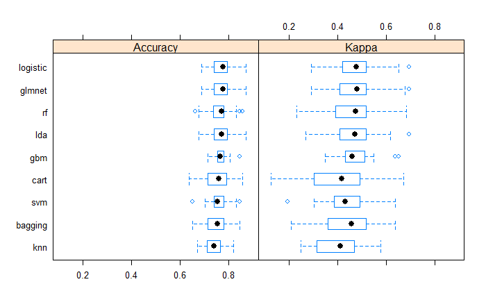

```r
bwplot(results)
```

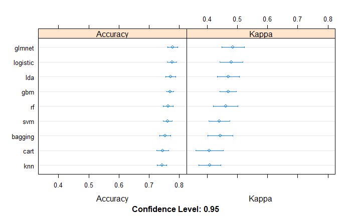

```r
# Dot-plot comparison
dotplot(results)
```

## Exercise

Investigate caret package and compare at least 5 regression models on Auto data set. Use 5x2 CV approach. Why this can be a good way to compare models?